# Comparing log normal to normal distribution models

Nitay Alon

10/31/2018

In this report we’ll compare and analyze the difference between the normal and log-normal model for gender mixture data over brain features. The main goal is to test the mixture model hypothesis, described in the next section. In addition we examine the goodness of fit to decide which of the models fits the data better in terms of log-likelihood. We present the results of applying EM for MLE computation for each feature and analysis of the method and the results is presented.

## The data and hypothesis

In this paper we analyze the brain features of 1570 people, belonging to 2 groups - men and women. In this report we’ve analyzed 3 data files: GSP FS volume and measures and GSP VMB. The data quality process included removal of missing data, validation of positivity (measure cannot be negative) and labeling the subject sex.In addition we’ve applied scaling on the data (standardization). We assume that the measurements of brain features are sampled from distribution $f_X(x)$. We assume that each person in the data sample the measurement of its feature from one of two distributions: $f_1(x), f_2(x)$. The model in question is a mixture model, *that is*, we assume that the men and women brain data is a mixture of two distributions and not a pure distribution (pure type model).To test this hypothesis we use log-likelihood ratio test (llrt).

## EM algorithm for mixture of two populations and two samples

Under the alternative hypothesis we assume that the gender data is a mixture of two sex mixture. To estimate the MLE under this hypothesis we used the EM algorithm (Dempster,Laired,Rubin 1977).

The alternative model assumes the following:

The MLE’s under the null hypothesis are the usual MLE for normal data.

## Analysis and discussion

In this section we discuss the findings form the EM and llrt and compare the normal vs log normal assumption.

### GSP_FS_thickness+sex+age

We begin with the first GSP file. The algorithm was applied as described above and the results of both log-normal and normal model are presented bellow.

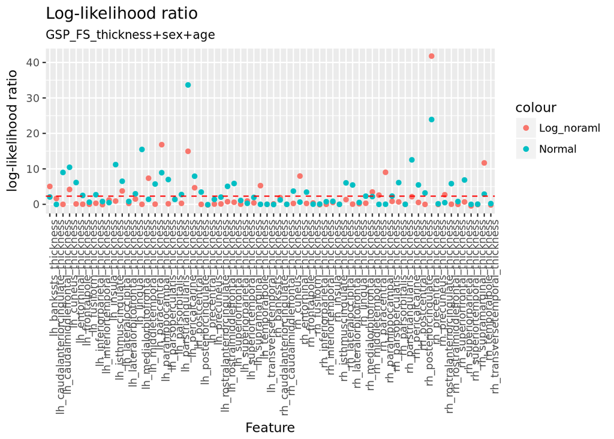

```r
library(ggplot2)
library(gridExtra)
llrt_per_feature <- ggplot(llrt_results_df, aes(Feature)) +
  geom_point(aes(y = Log_noraml, colour = "Log_noraml")) +
  geom_point(aes(y = Normal, colour = "Normal"))
llrt_per_feature + theme(axis.text.x = element_text(angle = 90, hjust = 1)) +
  ggtitle("Log-likelihood ratio", subtitle = "GSP_FS_thickness+sex+age") + geom_hline(yintercept=qexp(0.99,2), linetype="dashed", color = "red") + ylab("log-likelihood ratio")
```

The dashed red line marks the $99$ quantile of $exp(2)$ distribution, corresponding to the asymptotic distribution of the log likelihood ratio (Wilks’ theorem) and the proper rejecting region under FDR. The first noticeable fact is that there’s more discoveries under the normal distribution assumption than the log normal assumption, this worth further inquiry.

#### Handling identifabily issue

Let’s focus on the features with the lowest llrt.

```
## gdata: read.xls support for 'XLS' (Excel 97-2004) files ENABLED.
```

```
## gdata: read.xls support for 'XLSX' (Excel 2007+) files ENABLED.
```

if we plot a histogram of this feature:

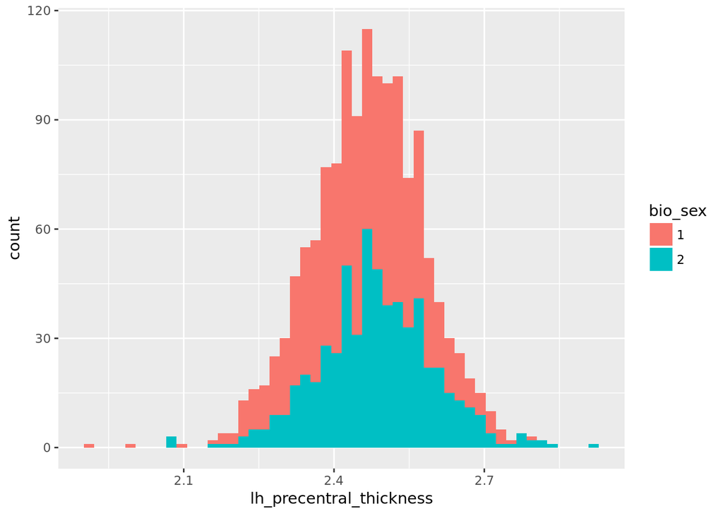

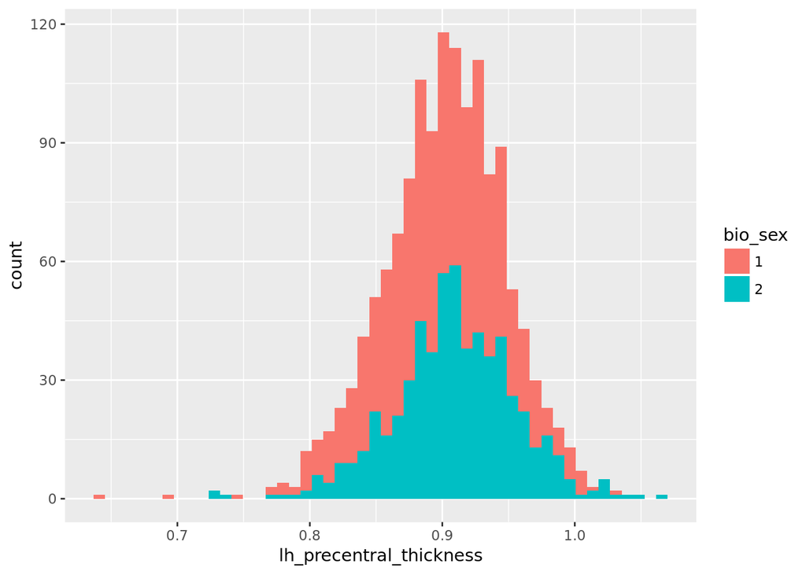

```r
raw_data_plot <- plotBrainFeature(brain_feature_scaled,F)
raw_data_plot
```

And the scaled data histogram:

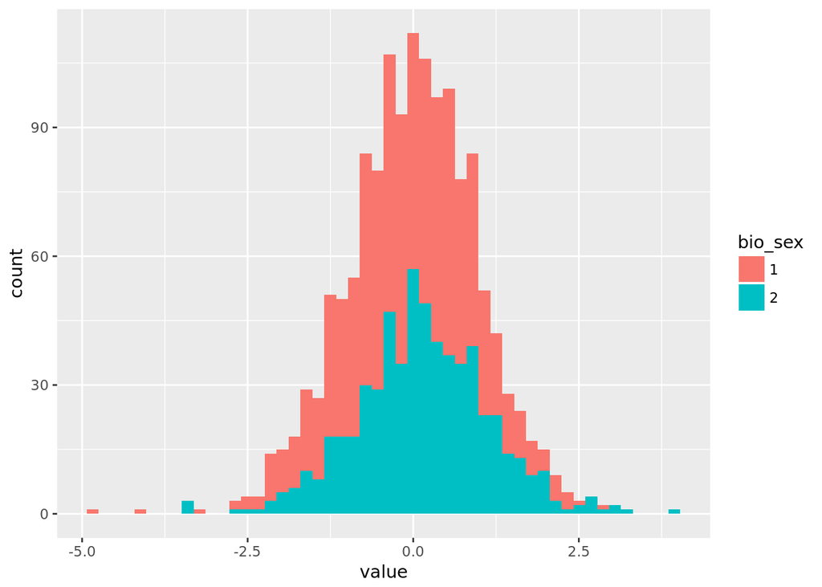

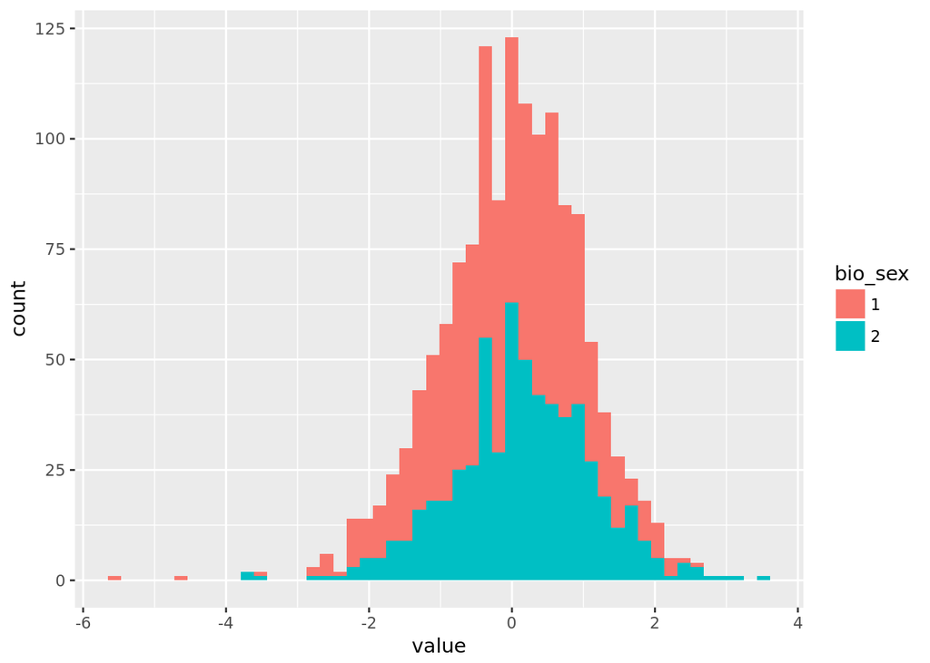

```r
raw_data_plot <- plotBrainFeature(brain_feature_scaled,T)
raw_data_plot
```

Looking at the plots, there’s a reason to believe that the mixture model hypothesis is more likely than the null hypothesis. The last claim can be justified by observing that some observations are relatively far from the center mass. We’ll re-run the EM algorithm on this feature and analyze the results.

[output not shown]

[output not shown]

[output not shown]

[output not shown]

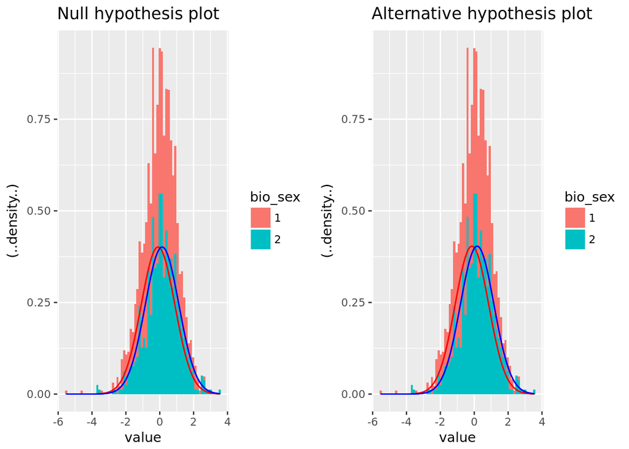

here we can see that we get two different distributions with the same likelihood, which might indicate a label switching problem. To test this problem, let’s apply the EM again but with more iterations.

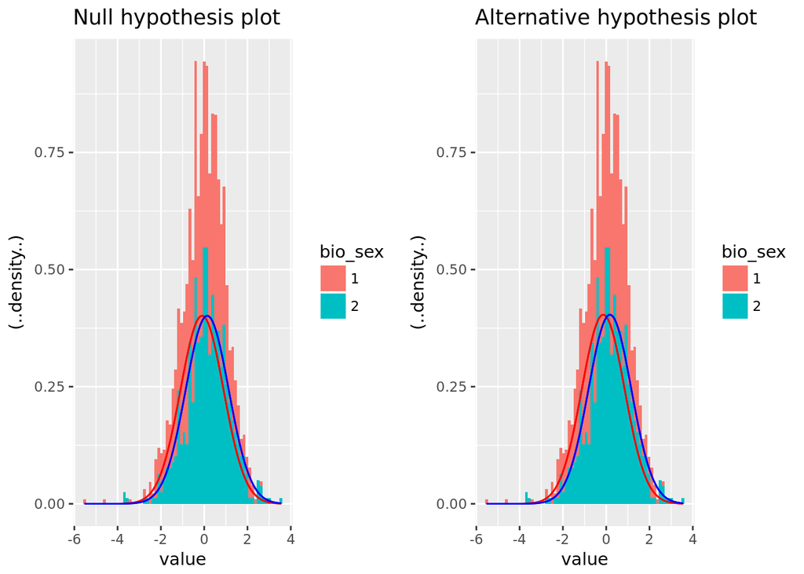

```r
em_log_normal <- createEMClassForFeature(feature_name, T, brain_feature_scaled@scaled_log_value)

men <- em_log_normal@data_file$value[em_log_normal@data_file$bio_sex == 1]
women <- em_log_normal@data_file$value[em_log_normal@data_file$bio_sex == 2]
men_mean <- mean(men)
women_mean <- mean(women)
null_var <- computePooledVariance(men,women)

null_plot <- ggplot(em_log_normal@data_file, aes(value, fill = bio_sex)) +
  geom_histogram(bins = 70, aes(y = (..density..))) +
  stat_function(fun = dnorm, colour = "red", args = list(mean = men_mean, sd = sqrt(null_var))) +
  stat_function(fun = dnorm, colour = "blue", args = list(mean = women_mean, sd = sqrt(null_var))) + ggtitle("Null hypothesis plot")


mas_mean = em_log_normal@EM_results$EM_results$m_parameters$mu_1
fem_mean = em_log_normal@EM_results$EM_results$m_parameters$mu_2
alt_var = em_log_normal@EM_results$EM_results$m_parameters$sigma_2

alternative_plot <- ggplot(em_log_normal@data_file, aes(value, fill = bio_sex)) +
  geom_histogram(bins = 70, aes(y = (..density..))) +
  stat_function(fun = dnorm, colour = "red", args = list(mean = mas_mean, sd = sqrt(alt_var))) +
  stat_function(fun = dnorm, colour = "blue", args = list(mean = fem_mean, sd = sqrt(alt_var))) + ggtitle("Alternative hypothesis plot")

grid.arrange(null_plot,alternative_plot, ncol = 2, nrow = 1)
```

And the results are practically the same, leading us to believe that there’s indeed ineffability issue in this feature. It is possible that in other features with low llrt and small disagreement between the normal and log normal models the situation is the same.

#### Exploring disagreements between the models

Next we explore features with high disagreement between the normal and log normal model. To do so let’s select the features with the highest “conflict” between the models.

```r
llrt_results_df$diff <- llrt_results_df$Log_noraml - llrt_results_df$Normal
normal_feature <- llrt_results_df$Feature[which.min(llrt_results_df$diff)]
log_normal_feature <- llrt_results_df$Feature[which.max(llrt_results_df$diff)]
```

Apply EM on the normal favored feature

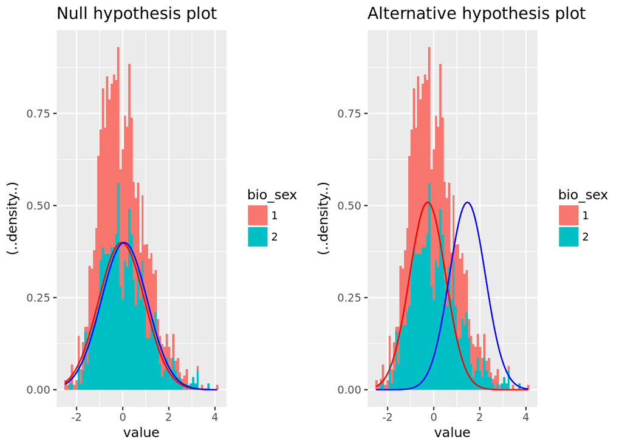

```r
normal_brain_feature <- loadBrainFeatureData(brain_feature,
                                          brain_file_data_with_data,
                                          normal_feature)
normal_brain_feature_log <- applyLogTransformationOnBrainFeatureData(normal_brain_feature)
normal_brain_feature_scaled <- applyScalingOnBrainFeatureData(normal_brain_feature_log)

em_normal <- createEMClassForFeature(normal_feature, F, normal_brain_feature_scaled@scaled_value)

men <- em_normal@data_file$value[em_log_normal@data_file$bio_sex == 1]
women <- em_normal@data_file$value[em_log_normal@data_file$bio_sex == 2]
men_mean <- mean(men)
women_mean <- mean(women)
null_var <- computePooledVariance(men,women)

null_plot <- ggplot(em_normal@data_file, aes(value, fill = bio_sex)) +
  geom_histogram(bins = 70, aes(y = (..density..))) +
  stat_function(fun = dnorm, colour = "red", args = list(mean = men_mean, sd = sqrt(null_var))) +
  stat_function(fun = dnorm, colour = "blue", args = list(mean = women_mean, sd = sqrt(null_var))) + ggtitle("Null hypothesis plot")


mas_mean = em_normal@EM_results$EM_results$m_parameters$mu_1
fem_mean = em_normal@EM_results$EM_results$m_parameters$mu_2
alt_var = em_normal@EM_results$EM_results$m_parameters$sigma_2

alternative_plot <- ggplot(em_normal@data_file, aes(value, fill = bio_sex)) +
  geom_histogram(bins = 70, aes(y = (..density..))) +
  stat_function(fun = dnorm, colour = "red", args = list(mean = mas_mean, sd = sqrt(alt_var))) +
  stat_function(fun = dnorm, colour = "blue", args = list(mean = fem_mean, sd = sqrt(alt_var))) + ggtitle("Alternative hypothesis plot")

grid.arrange(null_plot,alternative_plot, ncol = 2, nrow = 1)
```

And compare the results to the same data but with log normal assumption:

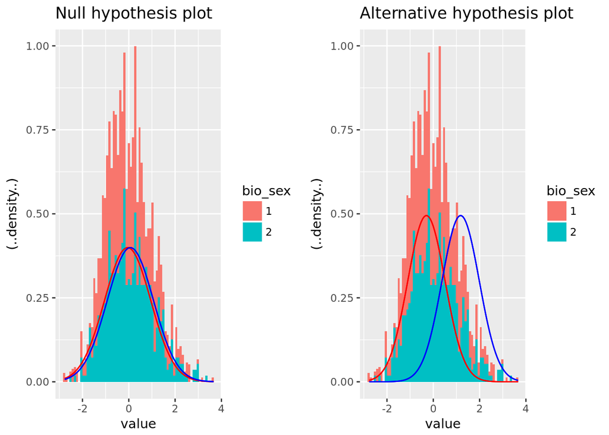

```r
em_log_normal <- createEMClassForFeature(normal_feature, T, normal_brain_feature_scaled@scaled_log_value)

men <- em_log_normal@data_file$value[em_log_normal@data_file$bio_sex == 1]
women <- em_log_normal@data_file$value[em_log_normal@data_file$bio_sex == 2]
men_mean <- mean(men)
women_mean <- mean(women)
null_var <- computePooledVariance(men,women)

null_plot <- ggplot(em_log_normal@data_file, aes(value, fill = bio_sex)) +
  geom_histogram(bins = 70, aes(y = (..density..))) +
  stat_function(fun = dnorm, colour = "red", args = list(mean = men_mean, sd = sqrt(null_var))) +
  stat_function(fun = dnorm, colour = "blue", args = list(mean = women_mean, sd = sqrt(null_var))) + ggtitle("Null hypothesis plot")


mas_mean = em_log_normal@EM_results$EM_results$m_parameters$mu_1
fem_mean = em_log_normal@EM_results$EM_results$m_parameters$mu_2
alt_var = em_log_normal@EM_results$EM_results$m_parameters$sigma_2

alternative_plot <- ggplot(em_log_normal@data_file, aes(value, fill = bio_sex)) +
  geom_histogram(bins = 70, aes(y = (..density..))) +
  stat_function(fun = dnorm, colour = "red", args = list(mean = mas_mean, sd = sqrt(alt_var))) +
  stat_function(fun = dnorm, colour = "blue", args = list(mean = fem_mean, sd = sqrt(alt_var))) + ggtitle("Alternative hypothesis plot")

grid.arrange(null_plot,alternative_plot, ncol = 2, nrow = 1)
```

And we can see that the results are very similar, up to small changes in the MLE of the alternative model. Next let’s look at a feature with high llrt under the log-normal model:

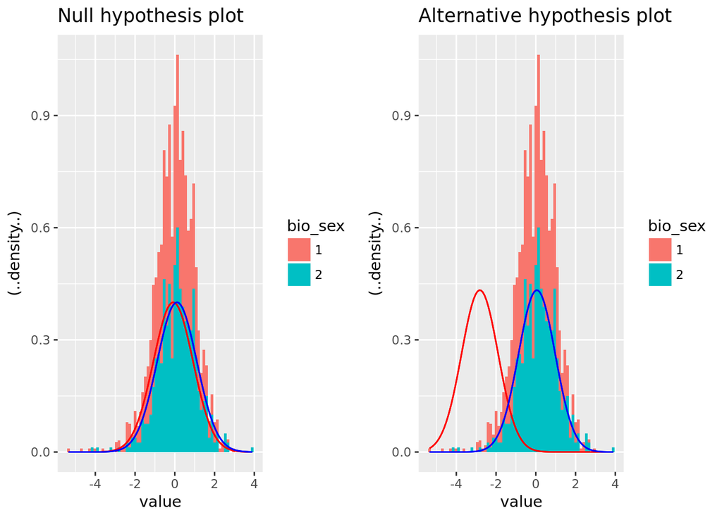

```r
log_normal_brain_feature <- loadBrainFeatureData(brain_feature,
                                          brain_file_data_with_data,
                                          log_normal_feature)
log_normal_brain_feature_log <- applyLogTransformationOnBrainFeatureData(log_normal_brain_feature)
log_normal_brain_feature_scaled <- applyScalingOnBrainFeatureData(log_normal_brain_feature_log)

em_normal <- createEMClassForFeature(normal_feature, F, log_normal_brain_feature_scaled@scaled_value)

men <- em_normal@data_file$value[em_log_normal@data_file$bio_sex == 1]
women <- em_normal@data_file$value[em_log_normal@data_file$bio_sex == 2]
men_mean <- mean(men)
women_mean <- mean(women)
null_var <- computePooledVariance(men,women)

null_plot <- ggplot(em_normal@data_file, aes(value, fill = bio_sex)) +
  geom_histogram(bins = 70, aes(y = (..density..))) +
  stat_function(fun = dnorm, colour = "red", args = list(mean = men_mean, sd = sqrt(null_var))) +
  stat_function(fun = dnorm, colour = "blue", args = list(mean = women_mean, sd = sqrt(null_var))) + ggtitle("Null hypothesis plot")


mas_mean = em_normal@EM_results$EM_results$m_parameters$mu_1
fem_mean = em_normal@EM_results$EM_results$m_parameters$mu_2
alt_var = em_normal@EM_results$EM_results$m_parameters$sigma_2

alternative_plot <- ggplot(em_normal@data_file, aes(value, fill = bio_sex)) +
  geom_histogram(bins = 70, aes(y = (..density..))) +
  stat_function(fun = dnorm, colour = "red", args = list(mean = mas_mean, sd = sqrt(alt_var))) +
  stat_function(fun = dnorm, colour = "blue", args = list(mean = fem_mean, sd = sqrt(alt_var))) + ggtitle("Alternative hypothesis plot")

grid.arrange(null_plot,alternative_plot, ncol = 2, nrow = 1)
```

Here we can see that the distribution match the type of distributions “classified” as good candidates for discovery using the KLD partition.

#### Summary GSP_FS_thickness+sex+age

Final we summarize the results of the llrt:

```r
library(knitr)
data_for_table <- data.frame(log_normal = nrow(llrt_results_df[llrt_results_df$Log_noraml > qexp(0.99,2),]),
                             normal = nrow(llrt_results_df[llrt_results_df$Normal > qexp(0.99,2),]),
                             number_of_features = nrow(llrt_results_df)
                               )
kable(data_for_table, caption = "log-likelihood ratio test")
```

log-likelihood ratio test

| log_normal | normal | number_of_features |
| --- | --- | --- |
| 15 | 31 | 68 |

### GSP_FS_volume_relevant+sex+age

Next we analyze the GSP FS volume file.

Plotting the results:

[figure not shown]

```r
llrt_per_feature <- ggplot(llrt_results_df, aes(Feature)) +
  geom_point(aes(y = Log_noraml, colour = "Log_noraml")) +
  geom_point(aes(y = Normal, colour = "Normal"))
llrt_per_feature + theme(axis.text.x = element_text(angle = 90, hjust = 1)) +
  ggtitle("Log-likelihood ratio", subtitle = "GSP_FS_thickness+sex+age") + geom_hline(yintercept=qexp(0.99,2), linetype="dashed", color = "red")
```

Here we see that the normal distribution assumption we get more discoveries.

```r
llrt_results_df$diff <- llrt_results_df$Log_noraml - llrt_results_df$Normal
```

Examining high llrt features:

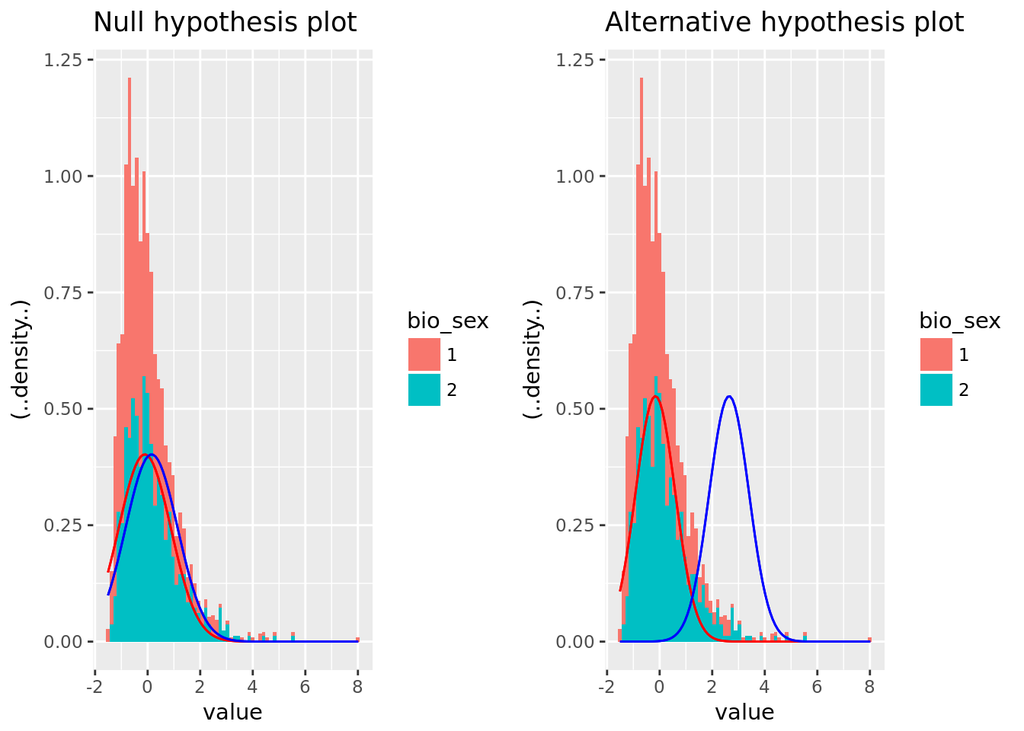

```r
load("~/mastersdegree/Thesis/DAPHNA_JOEL/Mixture_models/Log_normal_mixture_model/EM_Results/GSP_FS_volume_relevant+sex+ageBrain_file_class_")

normal_feature <- llrt_results_df$Feature[which.max(llrt_results_df$Normal)]

brain_feature <- new("brainFeatureData")
brain_feature <- loadBrainFeatureData(brain_feature,
                                          brain_file_data_with_data,
                                          normal_feature)
brain_feature_log <- applyLogTransformationOnBrainFeatureData(brain_feature)
brain_feature_scaled <- applyScalingOnBrainFeatureData(brain_feature_log)


normal_brain_feature <- loadBrainFeatureData(brain_feature,
                                          brain_file_data_with_data,
                                          normal_feature)
normal_brain_feature_log <- applyLogTransformationOnBrainFeatureData(normal_brain_feature)
normal_brain_feature_scaled <- applyScalingOnBrainFeatureData(normal_brain_feature_log)

em_normal <- createEMClassForFeature(normal_feature, F, normal_brain_feature_scaled@scaled_value)

men <- em_normal@data_file$value[em_normal@data_file$bio_sex == 1]
women <- em_normal@data_file$value[em_normal@data_file$bio_sex == 2]
men_mean <- mean(men)
women_mean <- mean(women)
null_var <- computePooledVariance(men,women)

null_plot <- ggplot(em_normal@data_file, aes(value, fill = bio_sex)) +
  geom_histogram(bins = 70, aes(y = (..density..))) +
  stat_function(fun = dnorm, colour = "red", args = list(mean = men_mean, sd = sqrt(null_var))) +
  stat_function(fun = dnorm, colour = "blue", args = list(mean = women_mean, sd = sqrt(null_var))) + ggtitle("Null hypothesis plot")


mas_mean = em_normal@EM_results$EM_results$m_parameters$mu_1
fem_mean = em_normal@EM_results$EM_results$m_parameters$mu_2
alt_var = em_normal@EM_results$EM_results$m_parameters$sigma_2

alternative_plot <- ggplot(em_normal@data_file, aes(value, fill = bio_sex)) +
  geom_histogram(bins = 70, aes(y = (..density..))) +
  stat_function(fun = dnorm, colour = "red", args = list(mean = mas_mean, sd = sqrt(alt_var))) +
  stat_function(fun = dnorm, colour = "blue", args = list(mean = fem_mean, sd = sqrt(alt_var))) + ggtitle("Alternative hypothesis plot")

grid.arrange(null_plot,alternative_plot, ncol = 2, nrow = 1)
```

Note that in this particular case the distribution follows a log normal shape. We repeat the same process for the second highest llrt:

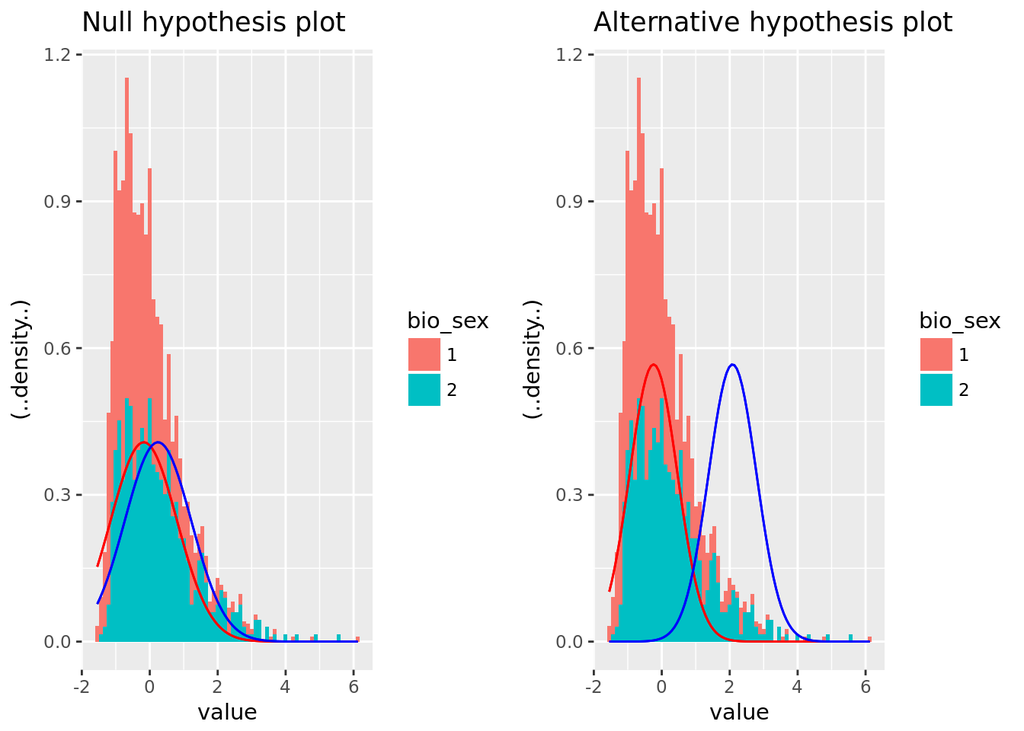

```r
normal_feature <- "left.lateral.ventricle"
brain_feature <- new("brainFeatureData")
brain_feature <- loadBrainFeatureData(brain_feature,
                                          brain_file_data_with_data,
                                          normal_feature)
brain_feature_log <- applyLogTransformationOnBrainFeatureData(brain_feature)
brain_feature_scaled <- applyScalingOnBrainFeatureData(brain_feature_log)

normal_brain_feature <- loadBrainFeatureData(brain_feature,
                                          brain_file_data_with_data,
                                          normal_feature)
normal_brain_feature_log <- applyLogTransformationOnBrainFeatureData(normal_brain_feature)
normal_brain_feature_scaled <- applyScalingOnBrainFeatureData(normal_brain_feature_log)

em_normal <- createEMClassForFeature(normal_feature, F, normal_brain_feature_scaled@scaled_value)

men <- em_normal@data_file$value[em_normal@data_file$bio_sex == 1]
women <- em_normal@data_file$value[em_normal@data_file$bio_sex == 2]
men_mean <- mean(men)
women_mean <- mean(women)
null_var <- computePooledVariance(men,women)

null_plot <- ggplot(em_normal@data_file, aes(value, fill = bio_sex)) +
  geom_histogram(bins = 70, aes(y = (..density..))) +
  stat_function(fun = dnorm, colour = "red", args = list(mean = men_mean, sd = sqrt(null_var))) +
  stat_function(fun = dnorm, colour = "blue", args = list(mean = women_mean, sd = sqrt(null_var))) + ggtitle("Null hypothesis plot")


mas_mean = em_normal@EM_results$EM_results$m_parameters$mu_1
fem_mean = em_normal@EM_results$EM_results$m_parameters$mu_2
alt_var = em_normal@EM_results$EM_results$m_parameters$sigma_2

alternative_plot <- ggplot(em_normal@data_file, aes(value, fill = bio_sex)) +
  geom_histogram(bins = 70, aes(y = (..density..))) +
  stat_function(fun = dnorm, colour = "red", args = list(mean = mas_mean, sd = sqrt(alt_var))) +
  stat_function(fun = dnorm, colour = "blue", args = list(mean = fem_mean, sd = sqrt(alt_var))) + ggtitle("Alternative hypothesis plot")

grid.arrange(null_plot,alternative_plot, ncol = 2, nrow = 1)
```

Again, similar distribution shape.

#### Summary

```r
data_for_table <- data.frame(log_normal = nrow(llrt_results_df[llrt_results_df$Log_noraml > qexp(0.99,2),]),
                             normal = nrow(llrt_results_df[llrt_results_df$Normal > qexp(0.99,2),]),
                             number_of_features = nrow(llrt_results_df)
                               )
kable(data_for_table, caption = "log-likelihood ratio test")
```

log-likelihood ratio test

| log_normal | normal | number_of_features |
| --- | --- | --- |
| 51 | 135 | 169 |

### GPS VBM

Last we repeat the analysis for the GSP VBM data file

Plotting the llrt:

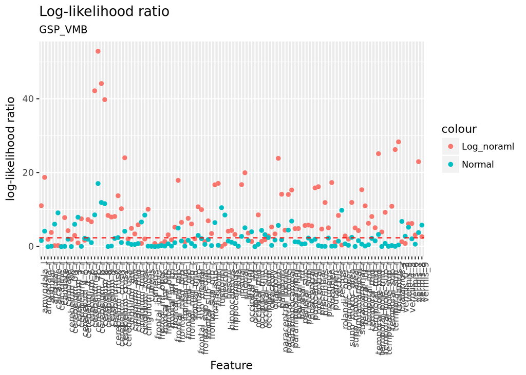

```r
llrt_per_feature <- ggplot(llrt_results_df[-1,], aes(Feature)) +
  geom_point(aes(y = Log_noraml, colour = "Log_noraml")) +
  geom_point(aes(y = Normal, colour = "Normal"))
llrt_per_feature + theme(axis.text.x = element_text(angle = 90, hjust = 1)) +
  ggtitle("Log-likelihood ratio", subtitle = "GSP_VMB") + geom_hline(yintercept=qexp(0.99,2), linetype="dashed", color = "red") + ylab("log-likelihood ratio")
```

Here we see an interesting pattern - the log normal model yields higher number of significant features, as presented in following table:

```r
data_for_table <- data.frame(log_normal = nrow(llrt_results_df[llrt_results_df$Log_noraml > qexp(0.99,2),]),
                             normal = nrow(llrt_results_df[llrt_results_df$Normal > qexp(0.99,2),]),
                             number_of_features = nrow(llrt_results_df)
                               )
kable(data_for_table, caption = "log-likelihood ratio test")
```

log-likelihood ratio test

| log_normal | normal | number_of_features |
| --- | --- | --- |
| 83 | 36 | 116 |

If we focus our intention to the highest llrt feature:

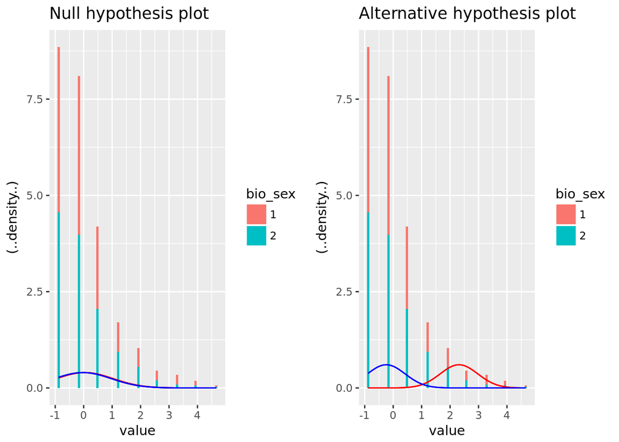

```r
log_normal_feature <- llrt_results_df$Feature[which.max(llrt_results_df$Log_noraml)]

brain_feature <- new("brainFeatureData")
brain_feature <- loadBrainFeatureData(brain_feature,
                                          brain_file_data_with_data,
                                          log_normal_feature)
brain_feature_log <- applyLogTransformationOnBrainFeatureData(brain_feature)
brain_feature_scaled <- applyScalingOnBrainFeatureData(brain_feature_log)

log_normal_brain_feature <- loadBrainFeatureData(brain_feature,
                                          brain_file_data_with_data,
                                          log_normal_feature)
log_normal_brain_feature_log <- applyLogTransformationOnBrainFeatureData(log_normal_brain_feature)
log_normal_brain_feature_scaled <- applyScalingOnBrainFeatureData(log_normal_brain_feature_log)

em_log_normal <- createEMClassForFeature(log_normal_feature, F, log_normal_brain_feature_scaled@scaled_value)

men <- em_log_normal@data_file$value[em_log_normal@data_file$bio_sex == 1]
women <- em_log_normal@data_file$value[em_log_normal@data_file$bio_sex == 2]
men_mean <- mean(men)
women_mean <- mean(women)
null_var <- computePooledVariance(men,women)

null_plot <- ggplot(em_log_normal@data_file, aes(value, fill = bio_sex)) +
  geom_histogram(bins = 70, aes(y = (..density..))) +
  stat_function(fun = dnorm, colour = "red", args = list(mean = men_mean, sd = sqrt(null_var))) +
  stat_function(fun = dnorm, colour = "blue", args = list(mean = women_mean, sd = sqrt(null_var))) + ggtitle("Null hypothesis plot")


mas_mean = em_log_normal@EM_results$EM_results$m_parameters$mu_1
fem_mean = em_log_normal@EM_results$EM_results$m_parameters$mu_2
alt_var = em_log_normal@EM_results$EM_results$m_parameters$sigma_2

alternative_plot <- ggplot(em_log_normal@data_file, aes(value, fill = bio_sex)) +
  geom_histogram(bins = 70, aes(y = (..density..))) +
  stat_function(fun = dnorm, colour = "red", args = list(mean = mas_mean, sd = sqrt(alt_var))) +
  stat_function(fun = dnorm, colour = "blue", args = list(mean = fem_mean, sd = sqrt(alt_var))) + ggtitle("Alternative hypothesis plot")

grid.arrange(null_plot,alternative_plot, ncol = 2, nrow = 1)
```

And here, again, we see a skewed distribution.

### Summary

In this report we’ve reviews the results of the mixture model vs pure type model. For each data file the results of the llrt were presented in table for ease of comparison between the log-normal and normal model. In addition some post-hoc analysis was done to understand the distribution structure of high llrt (strong mixture) features.

We begin with noting that for all three files we can claim that there is a string evidence in favor of the mixture model hypothesis, reflected by the high number of rejected llrt.

In addition we can see that there isn’t a strong pattern favoring the normal or log normal model, which might suggest that some features follow one distribution while the others follow the second.

We summarize by indicating that the features that had the highest llrt are the ones expected by the KLD schema.